# Cluster Analyse - Lösung

Joshua Simon

4 7 2021

## Aufgabe 6

### Teil a)

Bestimmen Sie auf Basis der quantitativen Merkmale die Distanz zwischen den drei Personen. Verwenden Sie dafür die *Minkowski-q-Metrik* mit $q = 1$ und $q = 2$.

*Lösung:*

Sei zunächst $q = 1$. Damit ergeben sich für die Distanzen $d_{ij}$ zwischen der $i$-ten und $j$-ten Beobachtung

$$\begin{align}
d_{12} & = \left( \lvert 55 - 23 \rvert + \lvert 2500 - 1800 \rvert + \lvert 4 - 3 \rvert \right) = 733 \\
d_{13} & = 1028 \\
d_{23} & = 1711
\end{align}$$

Sei nun $q = 2$. Die euklidschen Distanzen berechnen sich zu

$$\begin{align}
d_{12} & = \left( \lvert 55 - 23 \rvert^2 + \lvert 2500 - 1800 \rvert^2 + \lvert 4 - 3 \rvert^2 \right)^{\frac{1}{2}} = 700.7318 \\
d_{13} & = 1000.2960 \\
d_{23} & = 1700.0215
\end{align}$$

```python
import numpy as np
from math import sqrt

# Ex 6a)
def minkowski_norm(x_k, q):
    mean = np.mean(x_k)
    s = (1/len(x_k) * sum([abs(x - mean)**q for x in x_k]))**(1/q)
    return (np.array(x_k) - mean) / s

def minkowski_metric(x_i, x_j, q=2, norm=False):
    if norm:
        x_i = minkowski_norm(x_i, q)
        x_j = minkowski_norm(x_j, q)
    return sum([abs(i - j)**q for i, j in zip(x_i, x_j)])**(1/q)


x_1 = [55, 2500, 4]
x_2 = [23, 1800, 3]
x_3 = [31, 3500, 0]


print("Minkowski distance for q = 1:")
print(minkowski_metric(x_1, x_2, 1))
print(minkowski_metric(x_1, x_3, 1))
print(minkowski_metric(x_2, x_3, 1))
print("\n")

print("Minkowski distance for q = 2:")
print(minkowski_metric(x_1, x_2, 2))
print(minkowski_metric(x_1, x_3, 2))
print(minkowski_metric(x_2, x_3, 2))
print("\n")
```

```
Minkowski distance for q = 1:
733.0
1028.0
1711.0


Minkowski distance for q = 2:
700.7317603762513
1000.2959562049624
1700.021470452653
```

### Teil b)

Ist eine Skalierung der Merkmale in diesem Fall sinnvoll? Wie verandert sich das Ergebnis?

*Lösung:* Die *Minkowski-q-Metrik* ist nicht skaleninvariant, d.h. die Metrik verändert sich bei Sklaierung.

### Teil c)

Berechnen Sie für die qualitativen Merkmale die Ähnlichkeiten zwischen den Personen mittels eines M-Koeffizienten und eines S-Koeffizienten. Kodieren Sie dafür die Merkmale mit “Ja/m = 1” und “Nein/w = 0”.

*Lösung:*

Für die vorliegenden Beobachtungen ergeben sich die folgenden Kontingenztabellen.

- $i = 1$, $j = 2$: $\quad a = 0$, $b = 2$, $c = 0$, $d = 1$
- $i = 1$, $j = 3$: $\quad a = 1$, $b = 1$, $c = 1$, $d = 0$
- $i = 2$, $j = 3$: $\quad a = 0$, $b = 0$, $c = 2$, $d = 1$

```python
# Ex 6c)
def m_s_coeff(x_i, x_j, gamma=0.5, coeff="m"):
    a = 0
    b = 0
    c = 0
    d = 0

    for i, j in zip(x_i, x_j):
        if i == 1 and j == 1:
            a += 1
        elif i == 1 and j == 0:
            b += 1
        elif i == 0 and j == 1:
            c += 1
        elif i == 0 and j == 0:
            d += 1

    print(f"Table: a = {a}, b = {b}, c = {c}, d = {d}")

    if coeff == "m":
        s_ij = gamma * (a + d) / (gamma * (a + d) + (1 - gamma) * (b + c))
    elif coeff == "s":
        s_ij = gamma * a / (gamma * a + (1 - gamma) * (b + c))

    return s_ij


x_1 = [1, 1, 0]
x_2 = [0, 0, 0]
x_3 = [0, 1, 1]

print("M-Coefficients")
print("--------------")
print("Simple-Matching-Coefficient")
print(m_s_coeff(x_1, x_2, gamma=0.5))
print(m_s_coeff(x_1, x_3, gamma=0.5))
print(m_s_coeff(x_2, x_3, gamma=0.5))
print("\n")

print("Rogers and Tanimoto")
print(m_s_coeff(x_1, x_2, gamma=1/3))
print(m_s_coeff(x_1, x_3, gamma=1/3))
print(m_s_coeff(x_2, x_3, gamma=1/3))
print("\n")

print("Sokal and Sneath")
print(m_s_coeff(x_1, x_2, gamma=2/3))
print(m_s_coeff(x_1, x_3, gamma=2/3))
print(m_s_coeff(x_2, x_3, gamma=2/3))
print("\n")

print("S-Coefficients")
print("--------------")
print("Jaccard-Coefficient")
print(m_s_coeff(x_1, x_2, gamma=0.5, coeff="s"))
print(m_s_coeff(x_1, x_3, gamma=0.5, coeff="s"))
print(m_s_coeff(x_2, x_3, gamma=0.5, coeff="s"))
print("\n")

print("Sokal und Sneath")
print(m_s_coeff(x_1, x_2, gamma=1/3, coeff="s"))
print(m_s_coeff(x_1, x_3, gamma=1/3, coeff="s"))
print(m_s_coeff(x_2, x_3, gamma=1/3, coeff="s"))
print("\n")
```

```
M-Coefficients
--------------
Simple-Matching-Coefficient
Table: a = 0, b = 2, c = 0, d = 1
0.3333333333333333
Table: a = 1, b = 1, c = 1, d = 0
0.3333333333333333
Table: a = 0, b = 0, c = 2, d = 1
0.3333333333333333


Rogers and Tanimoto
Table: a = 0, b = 2, c = 0, d = 1
0.19999999999999998
Table: a = 1, b = 1, c = 1, d = 0
0.19999999999999998
Table: a = 0, b = 0, c = 2, d = 1
0.19999999999999998


Sokal and Sneath
Table: a = 0, b = 2, c = 0, d = 1
0.49999999999999994
Table: a = 1, b = 1, c = 1, d = 0
0.49999999999999994
Table: a = 0, b = 0, c = 2, d = 1
0.49999999999999994


S-Coefficients
--------------
Jaccard-Coefficient
Table: a = 0, b = 2, c = 0, d = 1
0.0
Table: a = 1, b = 1, c = 1, d = 0
0.3333333333333333
Table: a = 0, b = 0, c = 2, d = 1
0.0


Sokal und Sneath
Table: a = 0, b = 2, c = 0, d = 1
0.0
Table: a = 1, b = 1, c = 1, d = 0
0.19999999999999998
Table: a = 0, b = 0, c = 2, d = 1
0.0
```

### Teil d)

Das Merkmal Geschlecht könnte auch mit “w = 1” und “m = 0” kodiert werden. Hat diese eineindeutige Transformation einen Einfluss auf die Ähnlichkeiten?

*Lösung:* Nein.

### Teil e)

Welche Ansätze bestehen bei der Verwendung von unterschiedlichen Messniveaus?

*Lösung:* Vgl. Folie 198.

## Aufhabe 7

### Teil a)

Führen Sie eine Clusteranalyse nach dem *Single-Linkage-Verfahren* durch und erstellen Sie die kophenetische Matrix $D^\star$.

*Lösung:*

```r
D <- matrix(c(
  c(0.00, 0.80, 4.16, 3.28, 3.92, 4.69),
  c(0.80, 0.00, 4.14, 3.57, 4.00, 4.64),
  c(4.16, 4.14, 0.00, 2.71, 1.98, 2.15),
  c(3.28, 3.57, 2.71, 0.00, 3.16, 3.78),
  c(3.92, 4.00, 1.98, 3.16, 0.00, 2.52),
  c(4.69, 4.64, 2.15, 3.78, 2.52, 0.00)
), byrow = F, ncol = 6)

single_linkage <- hclust(as.dist(D), method="single")
single_linkage$height
```

```
## [1] 0.80 1.98 2.15 2.71 3.28
```

```r
cop_single_linkage=cophenetic(single_linkage)
cop_single_linkage
```

```
##      1    2    3    4    5
## 2 0.80
## 3 3.28 3.28
## 4 3.28 3.28 2.71
## 5 3.28 3.28 1.98 2.71
## 6 3.28 3.28 2.15 2.71 2.15
```

### Teil b)

Erstellen Sie das dazugehorige Dendrogramm zu der Clusterbildung.

*Lösung:*

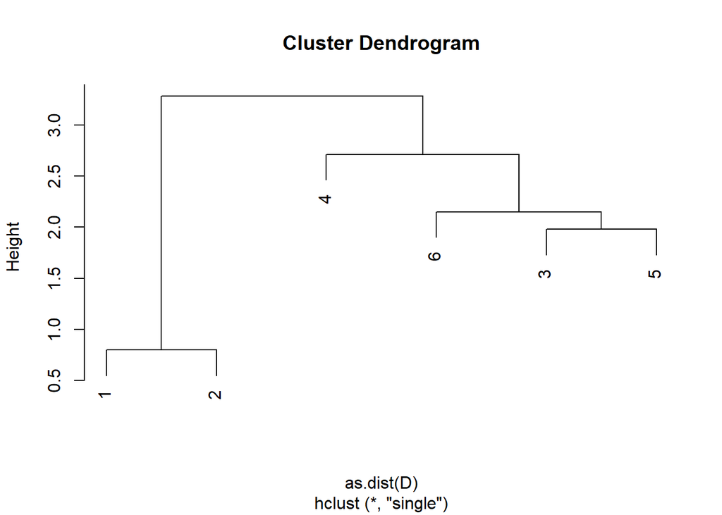

```r
plot(single_linkage)
```

### Teil c)

Bestimmen Sie die Anzahl der zu bildenden Segmente nach dem Test von Mojena.

*Lösung:*

```r
alpha <- single_linkage$height
alpha_mean <- mean(alpha)
alpha_std <- sd(alpha)

alpha_scale <- (alpha - alpha_mean) / alpha_std

i <- which(alpha_scale >= 2.5)[1]
i
```

```
## [1] NA
```

```r
if (is.na(i)) {
  i <- length(alpha_scale)
}

n <- nrow(D)
classes <- n + 1 - i
classes
```

```
## [1] 2
```

### Teil d)

Führen Sie für die Regionen das K-Means-Verfahren durch.

*Lösung:*

```r
data <- matrix(c(
  c(1524.8, 265.4, 272, 79, 24, 223.5),
  c(1596.9, 323.6, 285, 87, 23, 333.9),
  c(2299.7, 610.3, 241, 45, 9, 632.1),
  c(864.1, 303.9, 220, 53, 11, 484.7),
  c(2669.9, 645.5, 202, 61, 15, 438.6),
  c(2985.2, 571.2, 226, 45, 16, 1103.9)
), byrow = T, ncol = 6)

KM=kmeans(data,2)
KM
```

```
## K-means clustering with 2 clusters of sizes 3, 3
##
## Cluster means:
##     [,1]     [,2] [,3]     [,4]     [,5]     [,6]
## 1 1328.6 297.6333  259 73.00000 19.33333 347.3667
## 2 2651.6 609.0000  223 50.33333 13.33333 724.8667
##
## Clustering vector:
## [1] 1 1 2 1 2 2
##
## Within cluster sum of squares by cluster:
## [1] 365479.5 473414.1
##  (between_SS / total_SS =  78.1 %)
##
## Available components:
##
## [1] "cluster"      "centers"      "totss"        "withinss"     "tot.withinss"
## [6] "betweenss"    "size"         "iter"         "ifault"
```

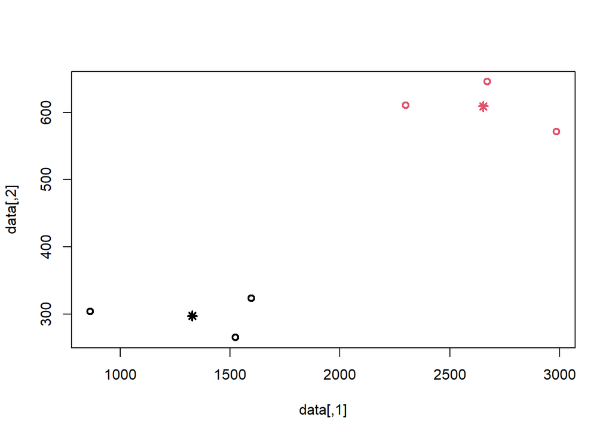

```r
plot(data, col = KM$cluster, lwd=2)
points(KM$centers, col=1:2, pch=8, lwd=2)
```